# GLM para dados categóricos

Gabriela Neres, Mariane Melo, Pedro Lopes

## 1 Introdução

Os pinguins passam por diferentes estágios de desenvolvimento ao longo de sua vida, desde filhotes até adultos. Cada estágio apresenta desafios fisiológicos e ecológicos distintos que podem influenciar sua condição corporal e saúde. Aqui utilizaremos **modelos multinomiais** para investigar a relação entre o estágio de vida e a condição de saúde (baixo peso, peso normal, sobrepeso) em pinguins do Arquipélago de Palmer.

## 2 Carregando os pacotes utilizados

```r
library(ggplot2) # Visualização dos gráficos
library(dplyr) # Manipulação dos dados
library(nnet) # Modelos multinomiais
library(tidyr) # Organização dos dados
```

## 3 Importação dos dados

```r
pinguins <- readRDS("Dados/palmerpenguins_extended.rds")

# Visualizar a estrutura dos dados
str(pinguins)
```

```
## 'data.frame':    3430 obs. of  11 variables:
##  $ species          : chr  "Adelie" "Adelie" "Adelie" "Adelie" ...
##  $ island           : chr  "Biscoe" "Biscoe" "Biscoe" "Biscoe" ...
##  $ bill_length_mm   : num  53.4 49.3 55.7 38 60.7 35.7 61 66.1 61.4 54.9 ...
##  $ bill_depth_mm    : num  17.8 18.1 16.6 15.6 17.9 16.8 20.8 20.8 19.9 22.3 ...
##  $ flipper_length_mm: num  219 245 226 221 177 194 211 246 270 230 ...
##  $ body_mass_g      : num  5687 6811 5388 6262 4811 ...
##  $ sex              : chr  "female" "female" "female" "female" ...
##  $ diet             : chr  "fish" "fish" "fish" "fish" ...
##  $ life_stage       : chr  "adult" "adult" "adult" "adult" ...
##  $ health_metrics   : chr  "overweight" "overweight" "overweight" "overweight" ...
##  $ year             : int  2021 2021 2021 2021 2021 2021 2021 2021 2021 2021 ...
```

O dataset contém informações morfométricas e biológicas de pinguins coletadas entre 2021-2025

## 4 Análise exploratória

```r
# Ver distribuição das variáveis
table(pinguins$health_metrics)
```

```
##
##     healthy  overweight underweight
##        1550        1167         713
```

```r
table(pinguins$life_stage)
```

```
##
##    adult    chick juvenile
##     1029      860     1541
```

Podemos ver que as variáveis que iremos utilizar são categóricas. As **métricas de saúde** dividem-se em:

- saudável;
- abaixo do peso;
- acima do peso.

Já os **estágios de vida** estão divididos em:

- filhote;
- juvenil;
- adulto.

### 4.1 Visualização das proporções

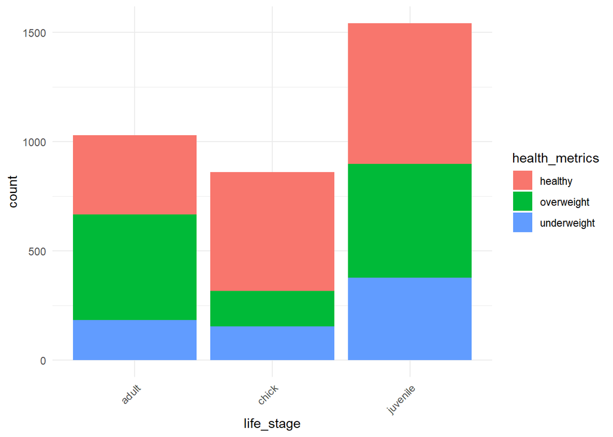

```r
ggplot(pinguins, aes(x = life_stage, fill = health_metrics)) +
  geom_bar() +
  theme_minimal() +
  theme(plot.title = element_text(hjust = 0.5),
        axis.text.x = element_text(angle = 45, hjust = 1))
```

Através do gráfico de barras é possível observar a proporção relativa de cada condição de saúde dos pinguins dentro de cada estágio de vida, dessa forma podemos visualizar alguns padrões preliminares, como qual estágio possui mais dados e maior proporção de sobrepeso ou baixo peso.

## 5 Modelo multinomial

Em modelos multinomiais, é preciso definir uma categoria de referência, de forma que todas as comparações serão feitas em relação a esta. Aqui escolhemos **“healthy” (peso normal)** como referência por ser o estado ideal de saúde.

```r
# Definir "healthy" como variável referência
pinguins$health_metrics <- relevel(as.factor(pinguins$health_metrics), ref = "healthy")

# Ajustar modelo
modelo <- multinom(health_metrics ~ life_stage, data = pinguins)
```

O modelo `health_metrics ~ life_stage` modela a probabilidade de cada condição de saúde em função do estágio de vida.

## 6 Resultados

### 6.1 Probabilidades preditas

```r
# Cálculo de probabilidades para cada estágio
novos_dados <- data.frame(life_stage = unique(pinguins$life_stage))
probabilidades <- predict(modelo, newdata = novos_dados, type = "probs")
resultados <- cbind(novos_dados, probabilidades)

print(round(resultados[, c("underweight", "healthy", "overweight")] * 100, 1))
```

```
##   underweight healthy overweight
## 1        17.8    35.2       47.0
## 2        24.5    41.8       33.7
## 3        17.8    63.3       19.0
```

As probabilidades preditas mostram a distribuição esperada de condições de saúde para cada estágio de vida, segundo o modelo. Valores foram convertidos em porcentagem para facilitar a interpretação.

### 6.2 Gráfico final

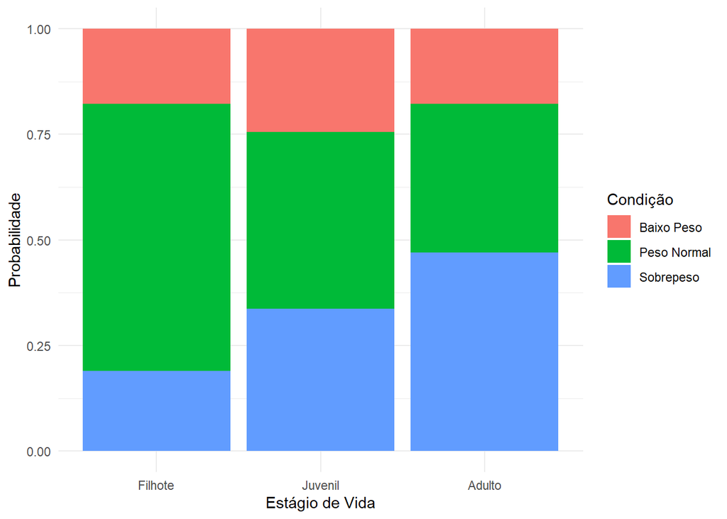

```r
# Preparar dados para o gráfico
dados_grafico <- resultados %>%
  pivot_longer(cols = -life_stage,
               names_to = "condicao_saude",
               values_to = "probabilidade") %>%
  mutate(
    condicao_saude = factor(condicao_saude,
                           levels = c("underweight", "healthy", "overweight"),
                           labels = c("Baixo Peso", "Peso Normal", "Sobrepeso")),
    life_stage = factor(life_stage,
                       levels = c("chick", "juvenile", "adult"),
                       labels = c("Filhote", "Juvenil", "Adulto"))
  )

# Gráfico de probabilidades
ggplot(dados_grafico, aes(x = life_stage, y = probabilidade, fill = condicao_saude)) +
  geom_col(position = "stack") +
  labs(x = "Estágio de Vida", y = "Probabilidade", fill = "Condição") +
  theme_minimal()
```

- **Estágio com maior risco de baixo peso: Juvenil (24,5%).** Isso pode se dar pelo período crítico de transição entre os estágios filhote e adulto.
- **Estágio com maior risco de sobrepeso: Adulto (47%).** Pode se relacionar com a menor atividade e/ou mudanças metabólicas (por exemplo: período reprodutivo).
- **Estágio com melhor condição: Filhote (63.3%).** Os pinguins apresentam cuidado parental e por isso a alimentação dos filhotes é controlada pelos pais, de forma a garantir a sobrevivência da prole.